# CompSciX 415.2 Homework 6

Yasmin Makoui

7/17/2018

```r
library(tidyverse)
library(mdsr)
library(mosaicData)
```

## Exercise 1

### Q1

#### What variables are in this data set?

- outcome
- smoker
- age

### Q2

#### How many observations are there and what does each represent?

##### There are 1,314 observations on women who were classified as current smokers or as never having smoked. Each observation has represts the following:

- outcome: survival status after 20 years: a factor with levels Alive Dead
- smoker: smoking status at baseline: a factor with levels No Yes
- age: age (in years) at the time of the first survey

### Q3

#### Create a table (use the R code below as a guide) and a visualization of the relationship between smoking status and outcome, ignoring age. What do you see? Does it make sense?

##### A tibble with 4 x 3 that shows the number of women who are alive or dead after 20 years depending on their smoking status. The tibble is not as informative because the proportion of dead women who don’t smoke relative to the women who did smoke are is bigger, and it’s not following expectations.

```r
library(mosaicData)
library(tidyverse)
Whickham %>% count(smoker,outcome)
```

```
## # A tibble: 4 x 3
##   smoker outcome     n
##   <fct>  <fct>   <int>
## 1 No     Alive     502
## 2 No     Dead      230
## 3 Yes    Alive     443
## 4 Yes    Dead      139
```

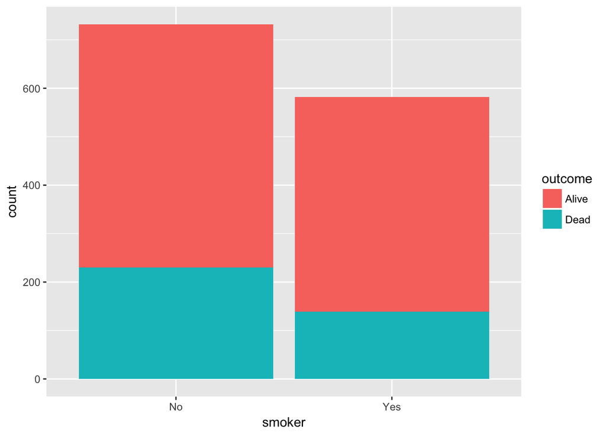

```r
ggplot(Whickham, mapping = aes(x = smoker, fill = outcome)) + geom_bar()
```

### Q4

#### Recode the age variable into an ordered factor with three categories: age <= 44, age > 44 & age <= 64, and age > 64. Now, recreate visualization from above, but facet on your new age factor. What do you see? Does it make sense?

##### I see a table with all the obsevations with a new column with the age factor. The results make sense for the women under the age of 65, since it shows a positive corrolation between smoking and death.

```r
whickham_age_fct <-Whickham %>% mutate(age_fct = case_when(age <= 44 ~ '44 and younger',
                                                     age > 44 & age <= 64 ~ 'Older than 44 to 64',
                                                     age > 64 ~ 'Older than 64'))

as_tibble(whickham_age_fct)
```

```
## # A tibble: 1,314 x 4
##    outcome smoker   age age_fct
##    <fct>   <fct>  <int> <chr>
##  1 Alive   Yes       23 44 and younger
##  2 Alive   Yes       18 44 and younger
##  3 Dead    Yes       71 Older than 64
##  4 Alive   No        67 Older than 64
##  5 Alive   No        64 Older than 44 to 64
##  6 Alive   Yes       38 44 and younger
##  7 Alive   Yes       45 Older than 44 to 64
##  8 Dead    No        76 Older than 64
##  9 Alive   No        28 44 and younger
## 10 Alive   No        27 44 and younger
## # ... with 1,304 more rows
```

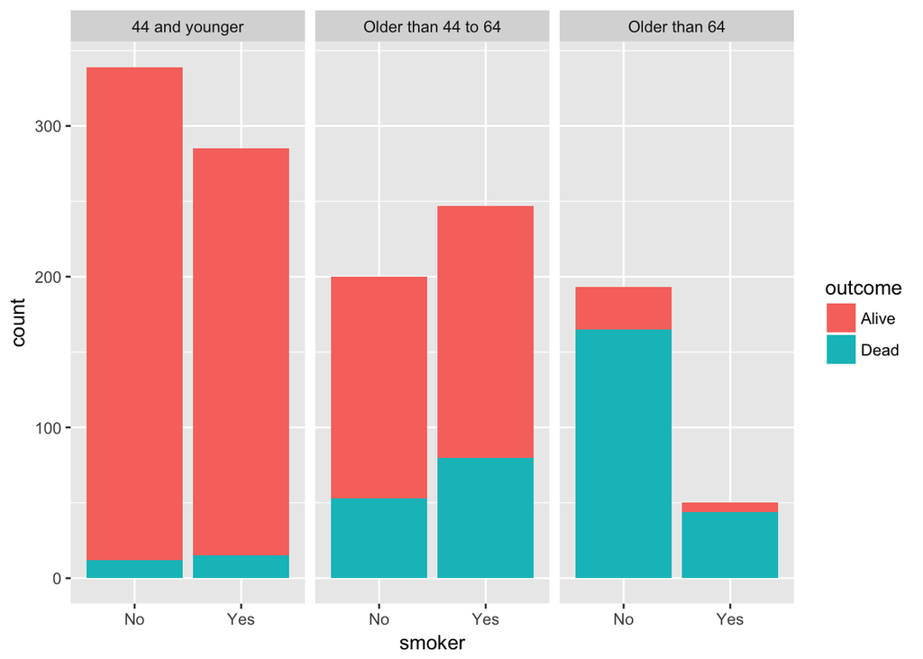

```r
whickham_age_fct %>% ggplot(mapping = aes(x = smoker, fill = outcome)) +
  geom_bar() + facet_wrap(~ age_fct)
```

## Exercise 2

##### The Central Limit Theorem states that the sampling distribution of sample means is approximately Normal, regardless of the distribution of your population. For this exercise our population distribution will be a Gamma(1,2) distribution, and we’ll show that the sampling distribution of the mean is in fact normally distributed.

### Q1

#### Generate a random sample of size n = 10000 from a gamma(1,2) distribution and plot a histogram or density curve. Use the code below to help you get your sample.

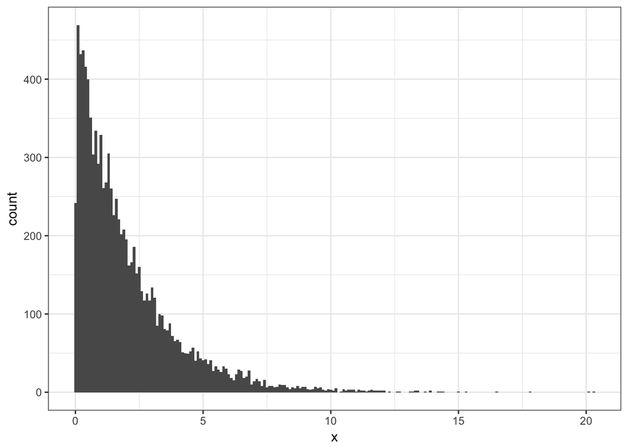

```r
library(tidyverse)
n <- 10000
# look at ?rgamma to read about this function
gamma_samp <- tibble(x = rgamma(n, shape = 1, scale = 2))
gamma_samp %>% ggplot() +
  geom_histogram(aes(x = x), binwidth = .1) + theme_bw()
```

### Q2

```r
mean_samp <- gamma_samp %>% .[['x']] %>% mean()
mean_samp
```

```
## [1] 2.004951
```

```r
sd_samp <- gamma_samp %>% .[['x']] %>% sd()
sd_samp
```

```
## [1] 1.992668
```

### Q3

#### Pretend the distribution of our population of data looks like the plot above. Now take a sample of size n = 30 from a Gamma(1,2) distribution, plot the histogram or density curve, and calculate the mean and standard deviation.

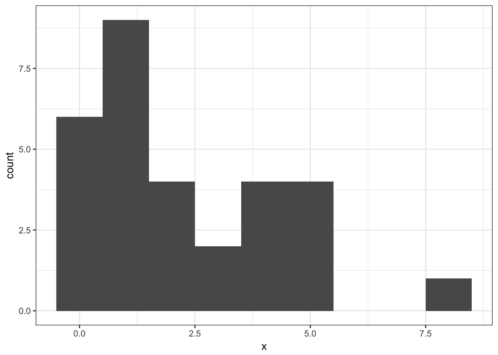

```r
n <- 30

gamma_samp_n30 <- tibble(x = rgamma(n, shape = 1, scale = 2))
gamma_samp_n30 %>% ggplot() +
  geom_histogram(aes(x = x), binwidth = 1) + theme_bw()
```

```r
mean_samp_n30 <- gamma_samp %>% .[['x']] %>% mean()
mean_samp_n30
```

```
## [1] 2.004951
```

```r
sd_samp_n30 <- gamma_samp %>% .[['x']] %>% sd()
sd_samp_n30
```

```
## [1] 1.992668
```

### Q4

#### Take a sample of size n = 30, again from the Gamma(1,2) distribution, calculate the mean, and assign it to a vector named mean_samp. Repeat this 10000 times!!!! The code below might help.

```r
n <- 30

gamma_samp_n30 <- tibble(x = rgamma(n, shape = 1, scale = 2))

mean_samp_n30 <- gamma_samp %>% .[['x']] %>% mean()
mean_samp_n30
```

```
## [1] 2.004951
```

```r
sd_samp_n30 <- gamma_samp %>% .[['x']] %>% sd()
sd_samp_n30
```

```
## [1] 1.992668
```

```r
# create a vector with 10000 NAs
mean_samp <- rep(NA, 10000)
# start a loop
for(i in 1:10000) {
g_samp <- rgamma(30, shape = 1, scale = 2)
mean_samp[i] <- mean(g_samp)
}
# Convert vector to a tibble
mean_samp <- tibble(mean_samp)
```

### Q5

#### Make a histogram of your collection of means from above (mean_samp).

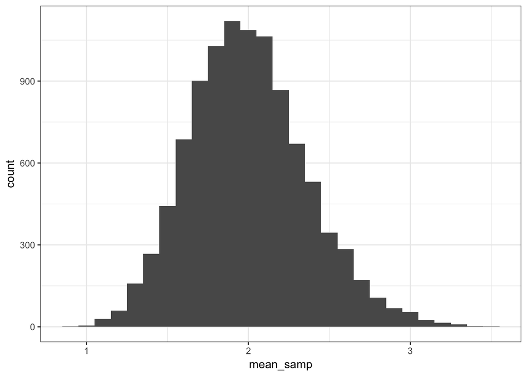

```r
n <- 30

gamma_samp_n30 <- tibble(x = rgamma(n, shape = 1, scale = 2))

mean_samp_n30 <- gamma_samp %>% .[['x']] %>% mean()

sd_samp_n30 <- gamma_samp %>% .[['x']] %>% sd()

# create a vector with 10000 NAs
mean_samp <- rep(NA, 10000)
# start a loop
for(i in 1:10000) {
g_samp <- rgamma(30, shape = 1, scale = 2)
mean_samp[i] <- mean(g_samp)
}
# Convert vector to a tibble
mean_samp <- tibble(mean_samp)
mean_samp %>% ggplot() +
  geom_histogram(aes(x = mean_samp), binwidth = .1) + theme_bw()
```

### Q6

#### Calculate the mean and standard deviation of all of your sample means.

```r
mean_samp_two <- mean_samp %>% .[['x']] %>% mean()
mean_samp_two
```

```
## [1] NA
```

```r
sd_samp_two <- mean_samp %>% .[['x']] %>% sd()
sd_samp_two
```

```
## [1] NA
```

### Q7

#### Did anything surprise you about your answers to #6?

##### The argument in not numeric or logical error was displayed

### Q8

```r
n <- 300

gamma_samp_n300 <- tibble(x = rgamma(n, shape = 1, scale = 2))

mean_samp_n300 <- gamma_samp %>% .[['x']] %>% mean()
mean_samp_n300
```

```
## [1] 2.004951
```

```r
sd_samp_n300 <- gamma_samp %>% .[['x']] %>% sd()
sd_samp_n300
```

```
## [1] 1.992668
```

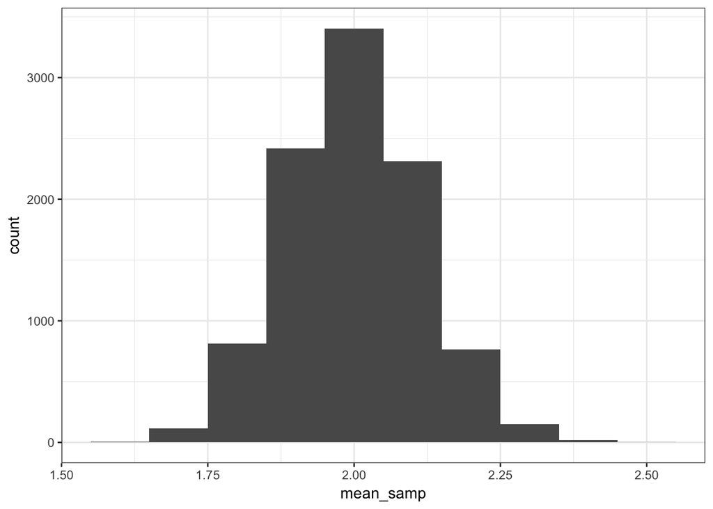

```r
# create a vector with 10000 NAs
mean_samp <- rep(NA, 10000)
# start a loop
for(i in 1:10000) {
g_samp <- rgamma(300, shape = 1, scale = 2)
mean_samp[i] <- mean(g_samp)
}
# Convert vector to a tibble
mean_samp <- tibble(mean_samp)
mean_samp %>% ggplot() +
  geom_histogram(aes(x = mean_samp), binwidth = .1) + theme_bw()
```